# new report

Lee Che Yuet Isaac

2023-04-17

**some of the codes have been hiden for easier reading purpose**

# Email mobilization

## Experimental groups

1. `0`: Control
2. `1`: Election Information
3. `2`: Social Pressure
4. `3`: Native Threat
5. `4`: Latino Group Threat.

## Counting experimental groups by treatment

```
## # A tibble: 6 × 2
##   treat        n
##   <dbl>    <int>
## 1     0   103742
## 2     1   103075
## 3     2   102414
## 4     3   102607
## 5     4   102812
## 6    NA 13528679
```

## Summary Statistics

```
##   gender            race        registrationYear     party        voterStatus
##  F   :173760   5      :206226   Min.   :1947     DEM    :121851   ACT:323736
##  M   :150624   4      : 64506   1st Qu.:2002     REP    :114575   INA:  7826
##  U   :  9563   3      : 38258   Median :2011     NPA    : 95267   PRE:  2440
##  NA's:    55   2      :  8283   Mean   :2007     LPF    :  1579
##                7      :  6592   3rd Qu.:2015     GRE    :   460
##                9      :  4450   Max.   :2016     IND    :    77
##                (Other):  5687                    (Other):   193
##  congressionalDistrict general16      outcome    historyCode2016  recent
##  19     : 19736        FALSE: 22227   0: 79731   A:150215        TRUE:254271
##  18     : 16583        TRUE :254271   1:254271   B:  1726        NA's: 79731
##  13     : 16117        NA's : 57504              N: 79731
##  14     : 15836                                  P:    76
##  16     : 14934                                  Y:102254
##  8      : 14677
##  (Other):236119
##   likely       general12      treat     registered_prior minority   major_party
##  TRUE:254271   FALSE:127798   0:67385   TRUE:334002      0:231238   1:121851
##  NA's: 79731   TRUE :148700   1:67030                    1:102764   2:114575
##                NA's : 57504   2:66573                               3: 97576
##                               3:66419
##                               4:66595
##
##
##       age         validEmail    pastGeneral   treated    democrat   republican
##  Min.   : 16.00   TRUE:334002   0   : 88799   0: 67385   0:212151   0:219427
##  1st Qu.: 28.00                 1   :187699   1:266617   1:121851   1:114575
##  Median : 44.00                 NA's: 57504
##  Mean   : 44.92
##  3rd Qu.: 61.00
##  Max.   :104.00
##
##  party_other  female       non_white
##  0:236426    0   :160187   0:231238
##  1: 97576    1   :173760   1:102764
##              NA's:    55
##
##
##
##
```

## Control vs Treatment

### Regression estimate

```
##
## Call:
## lm(formula = outcome ~ treated, data = em_cleaned)
##
## Residuals:
##     Min      1Q  Median      3Q     Max
## -0.7653  0.2347  0.2397  0.2397  0.2397
##
## Coefficients:
##              Estimate Std. Error t value Pr(>|t|)
## (Intercept)  0.765334   0.001642 466.040   <2e-16 ***
## treated     -0.005071   0.001838  -2.759   0.0058 **
## ---
## Signif. codes:  0 '***' 0.001 '**' 0.01 '*' 0.05 '.' 0.1 ' ' 1
##
## Residual standard error: 0.4263 on 334000 degrees of freedom
## Multiple R-squared:  2.279e-05,  Adjusted R-squared:  1.979e-05
## F-statistic: 7.611 on 1 and 334000 DF,  p-value: 0.005803
```

It has shown that the estimate of the ATT is -0.005071, with a p-value of 0.0058.

### Control regression estimate

Try adding other covariates into the regression and see

```
##
## Call:
## lm(formula = outcome ~ treated + age + female + race + party +
##     congressionalDistrict + historyCode2016 + general12, data = em_cleaned)
##
## Residuals:
##        Min         1Q     Median         3Q        Max
## -1.153e-11 -2.000e-14  0.000e+00  2.000e-14  2.259e-09
##
## Coefficients:
##                           Estimate Std. Error    t value Pr(>|t|)
## (Intercept)              1.000e+00  1.249e-12  8.007e+11  < 2e-16 ***
## treated                  9.214e-15  2.034e-14  4.530e-01  0.65061
## age                      8.231e-16  5.044e-16  1.632e+00  0.10270
## female                  -1.687e-14  1.651e-14 -1.022e+00  0.30668
## race2                   -6.814e-15  1.456e-13 -4.700e-02  0.96267
## race3                   -6.426e-14  1.379e-13 -4.660e-01  0.64133
## race4                    4.090e-15  1.368e-13  3.000e-02  0.97614
## race5                    7.666e-15  1.353e-13  5.700e-02  0.95482
## race6                   -8.379e-15  1.544e-13 -5.400e-02  0.95672
## race7                    5.115e-15  1.494e-13  3.400e-02  0.97269
## race9                   -8.528e-15  1.562e-13 -5.500e-02  0.95647
## partyCPF                -6.425e-15  1.345e-12 -5.000e-03  0.99619
## partyDEM                 3.626e-14  1.240e-12  2.900e-02  0.97668
## partyECO                 7.522e-14  1.895e-12  4.000e-02  0.96833
## partyGRE                 1.473e-14  1.259e-12  1.200e-02  0.99066
## partyIND                -1.067e-15  1.337e-12 -1.000e-03  0.99936
## partyLPF                 1.586e-14  1.246e-12  1.300e-02  0.98984
## partyNPA                 1.413e-14  1.241e-12  1.100e-02  0.99091
## partyPSL                 1.404e-14  1.491e-12  9.000e-03  0.99248
## partyREF                -7.725e-16  1.443e-12 -1.000e-03  0.99957
## partyREP                 1.255e-15  1.240e-12  1.000e-03  0.99919
## congressionalDistrict2  -2.568e-17  6.257e-14  0.000e+00  0.99967
## congressionalDistrict3  -3.116e-15  5.867e-14 -5.300e-02  0.95764
## congressionalDistrict4  -3.615e-15  6.188e-14 -5.800e-02  0.95342
## congressionalDistrict5   4.044e-15  6.590e-14  6.100e-02  0.95107
## congressionalDistrict6  -5.158e-15  6.603e-14 -7.800e-02  0.93774
## congressionalDistrict7  -3.409e-15  7.461e-14 -4.600e-02  0.96355
## congressionalDistrict8  -1.341e-14  5.788e-14 -2.320e-01  0.81683
## congressionalDistrict9  -5.988e-15  6.451e-14 -9.300e-02  0.92604
```

[output cut: 15 more lines]

```
## congressionalDistrict25 -6.195e-15  6.582e-14 -9.400e-02  0.92501
## congressionalDistrict26 -6.038e-15  6.418e-14 -9.400e-02  0.92505
## congressionalDistrict27 -1.206e-14  6.014e-14 -2.010e-01  0.84104
## historyCode2016B         3.939e-15  1.045e-13  3.800e-02  0.96993
## historyCode2016N        -1.000e+00  3.147e-14 -3.177e+13  < 2e-16 ***
## historyCode2016P         4.160e-15  4.932e-13  8.000e-03  0.99327
## historyCode2016Y        -3.338e-15  1.847e-14 -1.810e-01  0.85660
## general12TRUE            5.316e-15  1.756e-14  3.030e-01  0.76216
## ---
## Signif. codes:  0 '***' 0.001 '**' 0.01 '*' 0.05 '.' 0.1 ' ' 1
##
## Residual standard error: 4.297e-12 on 276418 degrees of freedom
##   (57532 observations deleted due to missingness)
## Multiple R-squared:      1,  Adjusted R-squared:      1
## F-statistic: 2.171e+25 on 51 and 276418 DF,  p-value: < 2.2e-16
```

The estimate of the ATT in this regression model with control variables is 9.214e-15 and a p-value of 0.65061, which is drastically different from the previous estimate. It could be impacted by the control variables tremendously.

### Covariate balance

```
## Balance Measures
##                             Type Diff.Un
## treated                   Binary  1.0000
## female                    Binary -0.0027
## race_1                    Binary -0.0001
## race_2                    Binary -0.0001
## race_3                    Binary -0.0010
## race_4                    Binary  0.0014
## race_5                    Binary -0.0007
## race_6                    Binary  0.0008
## race_7                    Binary -0.0004
## race_9                    Binary  0.0001
## party_AIP                 Binary  0.0000
## party_CPF                 Binary  0.0000
## party_DEM                 Binary  0.0025
## party_ECO                 Binary -0.0000
## party_GRE                 Binary  0.0001
## party_IND                 Binary -0.0001
## party_LPF                 Binary -0.0005
## party_NPA                 Binary -0.0029
## party_PSL                 Binary  0.0000
## party_REF                 Binary  0.0001
## party_REP                 Binary  0.0007
## congressionalDistrict_1   Binary -0.0008
## congressionalDistrict_2   Binary  0.0000
## congressionalDistrict_3   Binary -0.0035
## congressionalDistrict_4   Binary -0.0016
## congressionalDistrict_5   Binary  0.0004
## congressionalDistrict_6   Binary -0.0017
## congressionalDistrict_7   Binary -0.0017
## congressionalDistrict_8   Binary  0.0012
## congressionalDistrict_9   Binary -0.0002
## congressionalDistrict_10  Binary  0.0002
## congressionalDistrict_11  Binary  0.0006
## congressionalDistrict_12  Binary -0.0006
## congressionalDistrict_13  Binary -0.0002
## congressionalDistrict_14  Binary  0.0008
## congressionalDistrict_15  Binary  0.0007
## congressionalDistrict_16  Binary  0.0011
## congressionalDistrict_17  Binary  0.0017
## congressionalDistrict_18  Binary  0.0016
## congressionalDistrict_19  Binary  0.0023
## congressionalDistrict_20  Binary  0.0003
## congressionalDistrict_21  Binary -0.0001
## congressionalDistrict_22  Binary -0.0019
## congressionalDistrict_23  Binary  0.0006
## congressionalDistrict_24  Binary -0.0003
## congressionalDistrict_25  Binary  0.0010
## congressionalDistrict_26  Binary  0.0001
## congressionalDistrict_27  Binary -0.0001
## historyCode2016_A         Binary -0.0012
## historyCode2016_B         Binary -0.0000
## historyCode2016_N         Binary  0.0029
## historyCode2016_P         Binary -0.0002
## historyCode2016_Y         Binary -0.0015
## general12                 Binary  0.0005
## age                      Contin.  0.0015
##
## Sample sizes
##     Control Treated
## All   55934  220536
```

From the above covariate balance table, we can observe that the unadjusted differences of the covariates are not drastically different. One of the possible reasons is the datasets has a large amount of observations. The difference presented by the balance table between the control group and the treatment group could be reduced by the it. We can observe what will happen if different matching methods are applied on the dataset.

The Three chosen matching methods are Nearest Neighbor Matching, Exact Matching and Coarsened Exact Matching.

### Nearest neighbour matching

```
## Balance Measures
##                              Type Diff.Un Diff.Adj         M.Threshold
## distance                 Distance  0.0415   0.0000     Balanced, <0.01
## female                     Binary -0.0027  -0.0011     Balanced, <0.01
## race_1                     Binary -0.0001   0.0008     Balanced, <0.01
## race_2                     Binary -0.0001   0.0053     Balanced, <0.01
## race_3                     Binary -0.0010   0.0061     Balanced, <0.01
## race_4                     Binary  0.0014   0.0094     Balanced, <0.01
## race_5                     Binary -0.0007  -0.0283 Not Balanced, >0.01
## race_6                     Binary  0.0008   0.0004     Balanced, <0.01
## race_7                     Binary -0.0004   0.0037     Balanced, <0.01
## race_9                     Binary  0.0001   0.0026     Balanced, <0.01
## party_AIP                  Binary  0.0000  -0.0000     Balanced, <0.01
## party_CPF                  Binary  0.0000   0.0001     Balanced, <0.01
## party_DEM                  Binary  0.0025   0.0033     Balanced, <0.01
## party_ECO                  Binary -0.0000   0.0000     Balanced, <0.01
## party_GRE                  Binary  0.0001   0.0002     Balanced, <0.01
## party_IND                  Binary -0.0001   0.0001     Balanced, <0.01
## party_LPF                  Binary -0.0005   0.0003     Balanced, <0.01
## party_NPA                  Binary -0.0029   0.0120 Not Balanced, >0.01
## party_PSL                  Binary  0.0000   0.0000     Balanced, <0.01
## party_REF                  Binary  0.0001   0.0000     Balanced, <0.01
## party_REP                  Binary  0.0007  -0.0159 Not Balanced, >0.01
## congressionalDistrict_1    Binary -0.0008  -0.0024     Balanced, <0.01
## congressionalDistrict_2    Binary  0.0000  -0.0012     Balanced, <0.01
## congressionalDistrict_3    Binary -0.0035  -0.0019     Balanced, <0.01
## congressionalDistrict_4    Binary -0.0016  -0.0033     Balanced, <0.01
## congressionalDistrict_5    Binary  0.0004   0.0006     Balanced, <0.01
## congressionalDistrict_6    Binary -0.0017   0.0014     Balanced, <0.01
## congressionalDistrict_7    Binary -0.0017   0.0018     Balanced, <0.01
## congressionalDistrict_8    Binary  0.0012   0.0005     Balanced, <0.01
## congressionalDistrict_9    Binary -0.0002   0.0014     Balanced, <0.01
## congressionalDistrict_10   Binary  0.0002   0.0037     Balanced, <0.01
## congressionalDistrict_11   Binary  0.0006   0.0006     Balanced, <0.01
## congressionalDistrict_12   Binary -0.0006   0.0003     Balanced, <0.01
## congressionalDistrict_13   Binary -0.0002  -0.0012     Balanced, <0.01
## congressionalDistrict_14   Binary  0.0008  -0.0006     Balanced, <0.01
## congressionalDistrict_15   Binary  0.0007   0.0015     Balanced, <0.01
## congressionalDistrict_16   Binary  0.0011  -0.0022     Balanced, <0.01
## congressionalDistrict_17   Binary  0.0017  -0.0023     Balanced, <0.01
```

[output cut: 18 more lines]

```
## Balance tally for mean differences
##                     count
## Balanced, <0.01        50
## Not Balanced, >0.01     5
##
## Variable with the greatest mean difference
##  Variable Diff.Adj         M.Threshold
##    race_5  -0.0283 Not Balanced, >0.01
##
## Sample sizes
##                       Control Treated
## All                  55934.    220536
## Matched (ESS)        26964.02  220536
## Matched (Unweighted) 45718.    220536
## Unmatched            10216.         0
```

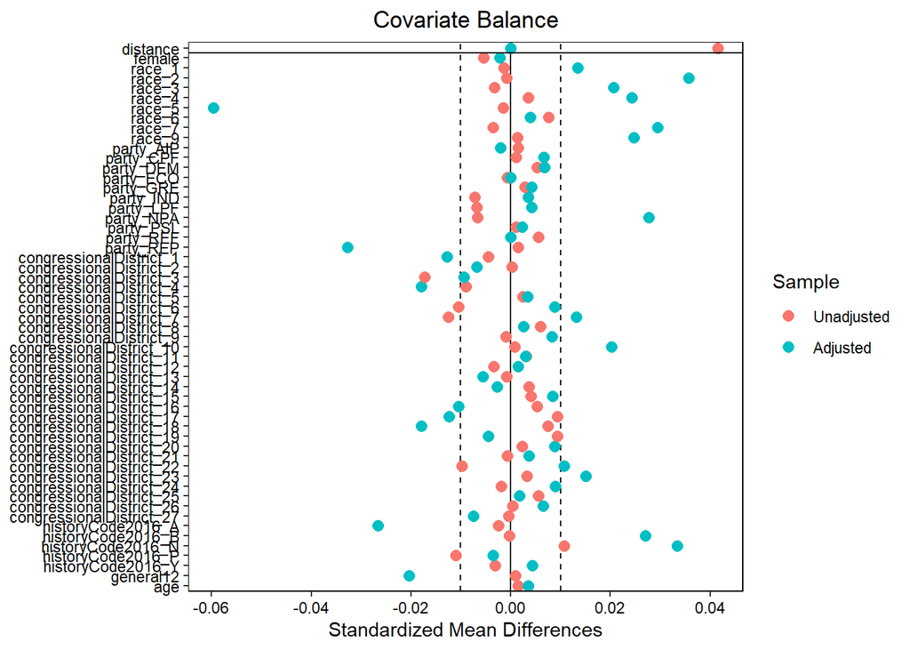

From the covariate balance table, we can see a large number of the adjusted difference are larger than the unadjusted difference, it may because of nearest neighbor matching does not give up treatment units that are far from being exactly matched, still match with the closest comparable unit.

#### ATT estimate by nearest neighbor matching

```
##
## Call:
## lm(formula = outcome ~ treated, data = em_m.data.nnm)
##
## Residuals:
##      Min       1Q   Median       3Q      Max
## -0.92228  0.08098  0.08098  0.08098  0.08098
##
## Coefficients:
##              Estimate Std. Error t value Pr(>|t|)
## (Intercept)  0.922284   0.001272 725.163   <2e-16 ***
## treated     -0.003264   0.001397  -2.336   0.0195 *
## ---
## Signif. codes:  0 '***' 0.001 '**' 0.01 '*' 0.05 '.' 0.1 ' ' 1
##
## Residual standard error: 0.2719 on 266252 degrees of freedom
## Multiple R-squared:  2.049e-05,  Adjusted R-squared:  1.674e-05
## F-statistic: 5.457 on 1 and 266252 DF,  p-value: 0.01949
```

### Exact matching

```
## Balance Measures
##                             Type Diff.Un Diff.Adj     M.Threshold
## female                    Binary -0.0027        0 Balanced, <0.01
## race_1                    Binary -0.0001        0 Balanced, <0.01
## race_2                    Binary -0.0001        0 Balanced, <0.01
## race_3                    Binary -0.0010        0 Balanced, <0.01
## race_4                    Binary  0.0014        0 Balanced, <0.01
## race_5                    Binary -0.0007        0 Balanced, <0.01
## race_6                    Binary  0.0008        0 Balanced, <0.01
## race_7                    Binary -0.0004        0 Balanced, <0.01
## race_9                    Binary  0.0001        0 Balanced, <0.01
## party_AIP                 Binary  0.0000        0 Balanced, <0.01
## party_CPF                 Binary  0.0000        0 Balanced, <0.01
## party_DEM                 Binary  0.0025        0 Balanced, <0.01
## party_ECO                 Binary -0.0000        0 Balanced, <0.01
## party_GRE                 Binary  0.0001        0 Balanced, <0.01
## party_IND                 Binary -0.0001        0 Balanced, <0.01
## party_LPF                 Binary -0.0005        0 Balanced, <0.01
## party_NPA                 Binary -0.0029        0 Balanced, <0.01
## party_PSL                 Binary  0.0000        0 Balanced, <0.01
## party_REF                 Binary  0.0001        0 Balanced, <0.01
## party_REP                 Binary  0.0007        0 Balanced, <0.01
## congressionalDistrict_1   Binary -0.0008        0 Balanced, <0.01
## congressionalDistrict_2   Binary  0.0000        0 Balanced, <0.01
## congressionalDistrict_3   Binary -0.0035        0 Balanced, <0.01
## congressionalDistrict_4   Binary -0.0016        0 Balanced, <0.01
## congressionalDistrict_5   Binary  0.0004        0 Balanced, <0.01
## congressionalDistrict_6   Binary -0.0017        0 Balanced, <0.01
## congressionalDistrict_7   Binary -0.0017        0 Balanced, <0.01
## congressionalDistrict_8   Binary  0.0012        0 Balanced, <0.01
## congressionalDistrict_9   Binary -0.0002        0 Balanced, <0.01
## congressionalDistrict_10  Binary  0.0002        0 Balanced, <0.01
## congressionalDistrict_11  Binary  0.0006        0 Balanced, <0.01
## congressionalDistrict_12  Binary -0.0006        0 Balanced, <0.01
## congressionalDistrict_13  Binary -0.0002        0 Balanced, <0.01
## congressionalDistrict_14  Binary  0.0008        0 Balanced, <0.01
## congressionalDistrict_15  Binary  0.0007        0 Balanced, <0.01
## congressionalDistrict_16  Binary  0.0011        0 Balanced, <0.01
## congressionalDistrict_17  Binary  0.0017        0 Balanced, <0.01
## congressionalDistrict_18  Binary  0.0016        0 Balanced, <0.01
```

[output cut: 17 more lines]

```
## Balance tally for mean differences
##                     count
## Balanced, <0.01        54
## Not Balanced, >0.01     0
##
## Variable with the greatest mean difference
##  Variable Diff.Adj     M.Threshold
##       age        0 Balanced, <0.01
##
## Sample sizes
##                       Control Treated
## All                  55934.    220536
## Matched (ESS)        26934.85  114270
## Matched (Unweighted) 43722.    114270
## Unmatched            12212.    106266
```

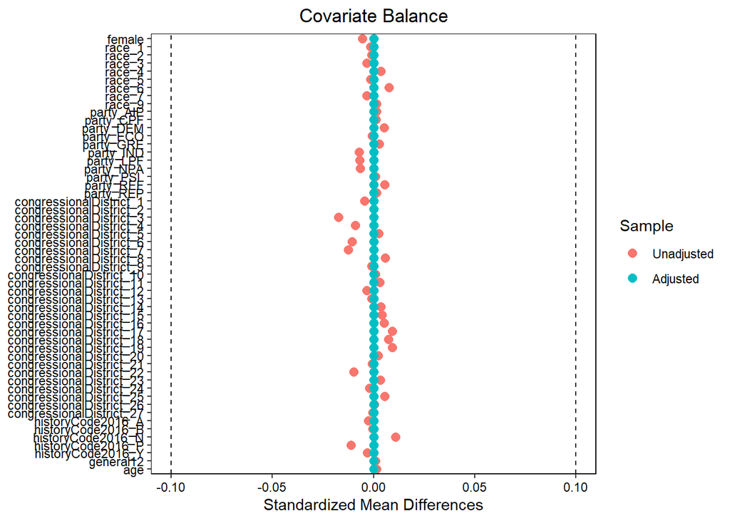

From the covariate balance table and loveplot, we can see that all of the adjusted difference are reduced to 0, it is because the unmatched units are all dropped.

#### ATT estimate by exact matching

```
##
## Call:
## lm(formula = outcome ~ treated, data = em_m.data.exa)
##
## Residuals:
##      Min       1Q   Median       3Q      Max
## -0.97566  0.02434  0.02434  0.04341  0.04341
##
## Coefficients:
##              Estimate Std. Error t value Pr(>|t|)
## (Intercept) 0.9565894  0.0008097 1181.39   <2e-16 ***
## treated     0.0190735  0.0009521   20.03   <2e-16 ***
## ---
## Signif. codes:  0 '***' 0.001 '**' 0.01 '*' 0.05 '.' 0.1 ' ' 1
##
## Residual standard error: 0.1693 on 157990 degrees of freedom
## Multiple R-squared:  0.002534,   Adjusted R-squared:  0.002527
## F-statistic: 401.3 on 1 and 157990 DF,  p-value: < 2.2e-16
```

The estimate for the ATT after using exact matching is 0.0190735, which has a p-value of less than 2e^-16.

### Coarsened Exact Matching

```
## Balance Measures
##                             Type Diff.Un Diff.Adj     M.Threshold
## female                    Binary -0.0027   0.0000 Balanced, <0.01
## race_1                    Binary -0.0001  -0.0000 Balanced, <0.01
## race_2                    Binary -0.0001   0.0000 Balanced, <0.01
## race_3                    Binary -0.0010   0.0000 Balanced, <0.01
## race_4                    Binary  0.0014  -0.0000 Balanced, <0.01
## race_5                    Binary -0.0007   0.0000 Balanced, <0.01
## race_6                    Binary  0.0008   0.0000 Balanced, <0.01
## race_7                    Binary -0.0004   0.0000 Balanced, <0.01
## race_9                    Binary  0.0001   0.0000 Balanced, <0.01
## party_AIP                 Binary  0.0000   0.0000 Balanced, <0.01
## party_CPF                 Binary  0.0000   0.0000 Balanced, <0.01
## party_DEM                 Binary  0.0025   0.0000 Balanced, <0.01
## party_ECO                 Binary -0.0000   0.0000 Balanced, <0.01
## party_GRE                 Binary  0.0001   0.0000 Balanced, <0.01
## party_IND                 Binary -0.0001   0.0000 Balanced, <0.01
## party_LPF                 Binary -0.0005   0.0000 Balanced, <0.01
## party_NPA                 Binary -0.0029   0.0000 Balanced, <0.01
## party_PSL                 Binary  0.0000   0.0000 Balanced, <0.01
## party_REF                 Binary  0.0001   0.0000 Balanced, <0.01
## party_REP                 Binary  0.0007   0.0000 Balanced, <0.01
## congressionalDistrict_1   Binary -0.0008   0.0000 Balanced, <0.01
## congressionalDistrict_2   Binary  0.0000   0.0000 Balanced, <0.01
## congressionalDistrict_3   Binary -0.0035   0.0000 Balanced, <0.01
## congressionalDistrict_4   Binary -0.0016   0.0000 Balanced, <0.01
## congressionalDistrict_5   Binary  0.0004  -0.0000 Balanced, <0.01
## congressionalDistrict_6   Binary -0.0017   0.0000 Balanced, <0.01
## congressionalDistrict_7   Binary -0.0017   0.0000 Balanced, <0.01
## congressionalDistrict_8   Binary  0.0012   0.0000 Balanced, <0.01
## congressionalDistrict_9   Binary -0.0002   0.0000 Balanced, <0.01
## congressionalDistrict_10  Binary  0.0002   0.0000 Balanced, <0.01
## congressionalDistrict_11  Binary  0.0006   0.0000 Balanced, <0.01
## congressionalDistrict_12  Binary -0.0006   0.0000 Balanced, <0.01
## congressionalDistrict_13  Binary -0.0002   0.0000 Balanced, <0.01
## congressionalDistrict_14  Binary  0.0008   0.0000 Balanced, <0.01
## congressionalDistrict_15  Binary  0.0007   0.0000 Balanced, <0.01
## congressionalDistrict_16  Binary  0.0011   0.0000 Balanced, <0.01
## congressionalDistrict_17  Binary  0.0017   0.0000 Balanced, <0.01
## congressionalDistrict_18  Binary  0.0016   0.0000 Balanced, <0.01
```

[output cut: 17 more lines]

```
## Balance tally for mean differences
##                     count
## Balanced, <0.01        54
## Not Balanced, >0.01     0
##
## Variable with the greatest mean difference
##  Variable Diff.Adj     M.Threshold
##       age  -0.0006 Balanced, <0.01
##
## Sample sizes
##                       Control Treated
## All                  55934.    220536
## Matched (ESS)        36276.23  174944
## Matched (Unweighted) 51293.    174944
## Unmatched             4641.     45592
```

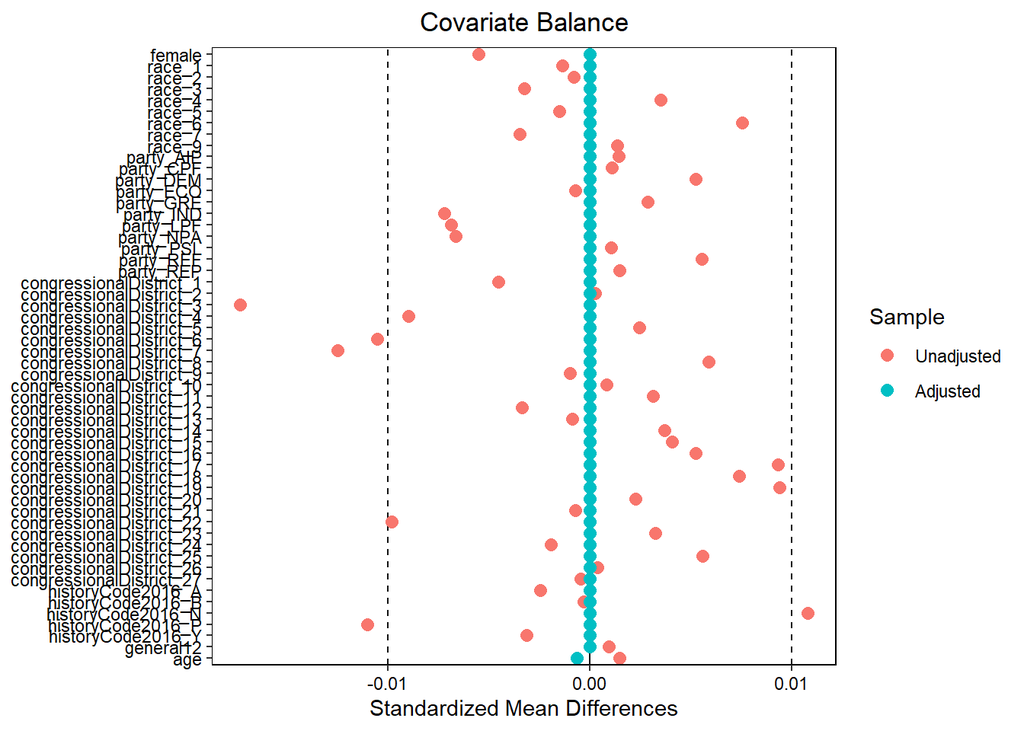

From the covariate balance table, we can see that most of the adjusted difference are reduced to 0, with the only exception of age, which is a continuous variable and may have a higher difficulty of being perfectly matched with too many possible discrete values.

From the loveplot, we can observe that all of the adjusted differences is smaller than the unadjusted difference.

#### ATT by coarsened exact matching

```
##
## Call:
## lm(formula = outcome ~ treated, data = em_m.data.cem)
##
## Residuals:
##      Min       1Q   Median       3Q      Max
## -0.95629  0.04371  0.04371  0.04371  0.06506
##
## Coefficients:
##              Estimate Std. Error t value Pr(>|t|)
## (Intercept) 0.9349424  0.0009481   986.1   <2e-16 ***
## treated     0.0213522  0.0010782    19.8   <2e-16 ***
## ---
## Signif. codes:  0 '***' 0.001 '**' 0.01 '*' 0.05 '.' 0.1 ' ' 1
##
## Residual standard error: 0.2147 on 226235 degrees of freedom
## Multiple R-squared:  0.00173,    Adjusted R-squared:  0.001726
## F-statistic: 392.2 on 1 and 226235 DF,  p-value: < 2.2e-16
```

The estimate for the ATT after using coarsened exact matching is 0.0213522, which has a p-value of less than 2e^-16.

### Comparing the ATT results from different matching

```
##
## Regression results after matching em
## ==================================================================================================================================
##                                                                  Dependent variable:
##                     --------------------------------------------------------------------------------------------------------------
##                                                                        outcome
##                                (1)                        (2)                        (3)                          (4)
## ----------------------------------------------------------------------------------------------------------------------------------
## Constant                    0.7653***                  0.9223***                  0.9566***                    0.9349***
##                              (0.0016)                  (0.0013)                    (0.0008)                     (0.0009)
##
## treated                     -0.0051***                 -0.0033**                  0.0191***                    0.0214***
##                              (0.0018)                  (0.0014)                    (0.0010)                     (0.0011)
##
## ----------------------------------------------------------------------------------------------------------------------------------
## Observations                 334,002                    266,254                    157,992                      226,237
## R2                           0.00002                    0.00002                     0.0025                       0.0017
## Adjusted R2                  0.00002                    0.00002                     0.0025                       0.0017
## Residual Std. Error    0.4263 (df = 334000)      0.2719 (df = 266252)        0.1693 (df = 157990)         0.2147 (df = 226235)
## F Statistic         7.6106*** (df = 1; 334000) 5.4568** (df = 1; 266252) 401.3233*** (df = 1; 157990) 392.1769*** (df = 1; 226235)
## ==================================================================================================================================
## Note:                                                                                                  *p<0.1; **p<0.05; ***p<0.01
```

## Control vs Treatment 1 (em1)

### Regression estimate

Creating a basic and preliminary estimate of the treatment effect.

```
##
## Call:
## lm(formula = outcome ~ treated, data = em1_cleaned)
##
## Residuals:
##     Min      1Q  Median      3Q     Max
## -0.7653  0.2347  0.2347  0.2388  0.2388
##
## Coefficients:
##              Estimate Std. Error t value Pr(>|t|)
## (Intercept)  0.765334   0.001638 467.374   <2e-16 ***
## treated     -0.004152   0.002319  -1.791   0.0734 .
## ---
## Signif. codes:  0 '***' 0.001 '**' 0.01 '*' 0.05 '.' 0.1 ' ' 1
##
## Residual standard error: 0.4251 on 134413 degrees of freedom
## Multiple R-squared:  2.385e-05,  Adjusted R-squared:  1.641e-05
## F-statistic: 3.206 on 1 and 134413 DF,  p-value: 0.07337
```

It has shown that the estimate of the ATT is -0.004152, with a p-value of 0.0734.

### Control regression estimate

Try adding other covariates into the regression and see

```
##
## Call:
## lm(formula = outcome ~ treated + age + female + race + party +
##     congressionalDistrict + historyCode2016 + general12, data = em_cleaned)
##
## Residuals:
##        Min         1Q     Median         3Q        Max
## -1.153e-11 -2.000e-14  0.000e+00  2.000e-14  2.259e-09
##
## Coefficients:
##                           Estimate Std. Error    t value Pr(>|t|)
## (Intercept)              1.000e+00  1.249e-12  8.007e+11  < 2e-16 ***
## treated                  9.214e-15  2.034e-14  4.530e-01  0.65061
## age                      8.231e-16  5.044e-16  1.632e+00  0.10270
## female                  -1.687e-14  1.651e-14 -1.022e+00  0.30668
## race2                   -6.814e-15  1.456e-13 -4.700e-02  0.96267
## race3                   -6.426e-14  1.379e-13 -4.660e-01  0.64133
## race4                    4.090e-15  1.368e-13  3.000e-02  0.97614
## race5                    7.666e-15  1.353e-13  5.700e-02  0.95482
## race6                   -8.379e-15  1.544e-13 -5.400e-02  0.95672
## race7                    5.115e-15  1.494e-13  3.400e-02  0.97269
## race9                   -8.528e-15  1.562e-13 -5.500e-02  0.95647
## partyCPF                -6.425e-15  1.345e-12 -5.000e-03  0.99619
## partyDEM                 3.626e-14  1.240e-12  2.900e-02  0.97668
## partyECO                 7.522e-14  1.895e-12  4.000e-02  0.96833
## partyGRE                 1.473e-14  1.259e-12  1.200e-02  0.99066
## partyIND                -1.067e-15  1.337e-12 -1.000e-03  0.99936
## partyLPF                 1.586e-14  1.246e-12  1.300e-02  0.98984
## partyNPA                 1.413e-14  1.241e-12  1.100e-02  0.99091
## partyPSL                 1.404e-14  1.491e-12  9.000e-03  0.99248
## partyREF                -7.725e-16  1.443e-12 -1.000e-03  0.99957
## partyREP                 1.255e-15  1.240e-12  1.000e-03  0.99919
## congressionalDistrict2  -2.568e-17  6.257e-14  0.000e+00  0.99967
## congressionalDistrict3  -3.116e-15  5.867e-14 -5.300e-02  0.95764
## congressionalDistrict4  -3.615e-15  6.188e-14 -5.800e-02  0.95342
## congressionalDistrict5   4.044e-15  6.590e-14  6.100e-02  0.95107
## congressionalDistrict6  -5.158e-15  6.603e-14 -7.800e-02  0.93774
## congressionalDistrict7  -3.409e-15  7.461e-14 -4.600e-02  0.96355
## congressionalDistrict8  -1.341e-14  5.788e-14 -2.320e-01  0.81683
## congressionalDistrict9  -5.988e-15  6.451e-14 -9.300e-02  0.92604
```

[output cut: 15 more lines]

```
## congressionalDistrict25 -6.195e-15  6.582e-14 -9.400e-02  0.92501
## congressionalDistrict26 -6.038e-15  6.418e-14 -9.400e-02  0.92505
## congressionalDistrict27 -1.206e-14  6.014e-14 -2.010e-01  0.84104
## historyCode2016B         3.939e-15  1.045e-13  3.800e-02  0.96993
## historyCode2016N        -1.000e+00  3.147e-14 -3.177e+13  < 2e-16 ***
## historyCode2016P         4.160e-15  4.932e-13  8.000e-03  0.99327
## historyCode2016Y        -3.338e-15  1.847e-14 -1.810e-01  0.85660
## general12TRUE            5.316e-15  1.756e-14  3.030e-01  0.76216
## ---
## Signif. codes:  0 '***' 0.001 '**' 0.01 '*' 0.05 '.' 0.1 ' ' 1
##
## Residual standard error: 4.297e-12 on 276418 degrees of freedom
##   (57532 observations deleted due to missingness)
## Multiple R-squared:      1,  Adjusted R-squared:      1
## F-statistic: 2.171e+25 on 51 and 276418 DF,  p-value: < 2.2e-16
```

It can be observed that the estimate for the treatment indicator has been largely reduced to 9.214e-15 and a p-value of 0.65061, hugely affected by other control variables.

### Covariate balance

```
## Balance Measures
##                             Type Diff.Un
## treated                   Binary  1.0000
## female                    Binary -0.0020
## race_1                    Binary -0.0001
## race_2                    Binary -0.0002
## race_3                    Binary  0.0008
## race_4                    Binary  0.0020
## race_5                    Binary -0.0044
## race_6                    Binary  0.0016
## race_7                    Binary -0.0002
## race_9                    Binary  0.0005
## party_AIP                 Binary  0.0000
## party_CPF                 Binary  0.0000
## party_DEM                 Binary  0.0046
## party_ECO                 Binary -0.0000
## party_GRE                 Binary -0.0000
## party_IND                 Binary -0.0001
## party_LPF                 Binary -0.0010
## party_NPA                 Binary  0.0001
## party_PSL                 Binary  0.0000
## party_REF                 Binary  0.0001
## party_REP                 Binary -0.0037
## congressionalDistrict_1   Binary  0.0036
## congressionalDistrict_2   Binary  0.0002
## congressionalDistrict_3   Binary -0.0035
## congressionalDistrict_4   Binary -0.0019
## congressionalDistrict_5   Binary  0.0003
## congressionalDistrict_6   Binary -0.0022
## congressionalDistrict_7   Binary -0.0018
## congressionalDistrict_8   Binary  0.0006
## congressionalDistrict_9   Binary  0.0002
## congressionalDistrict_10  Binary  0.0005
## congressionalDistrict_11  Binary  0.0007
## congressionalDistrict_12  Binary -0.0002
## congressionalDistrict_13  Binary -0.0014
## congressionalDistrict_14  Binary  0.0029
## congressionalDistrict_15  Binary  0.0005
## congressionalDistrict_16  Binary -0.0005
## congressionalDistrict_17  Binary  0.0015
## congressionalDistrict_18  Binary  0.0006
## congressionalDistrict_19  Binary  0.0032
## congressionalDistrict_20  Binary -0.0004
## congressionalDistrict_21  Binary -0.0014
## congressionalDistrict_22  Binary -0.0021
## congressionalDistrict_23  Binary  0.0012
## congressionalDistrict_24  Binary -0.0003
## congressionalDistrict_25  Binary -0.0003
## congressionalDistrict_26  Binary -0.0017
## congressionalDistrict_27  Binary  0.0020
## historyCode2016_A         Binary  0.0002
## historyCode2016_B         Binary -0.0001
## historyCode2016_N         Binary  0.0045
## historyCode2016_P         Binary -0.0001
## historyCode2016_Y         Binary -0.0045
## general12                 Binary -0.0012
## age                      Contin.  0.0016
##
## Sample sizes
##     Control Treated
## All   55934   55607
```

From the above covariate balance table, we can observe that the unadjusted differences of the covariates are almost 0. Similar situation to the mentioned analysis.

### Nearest neighbour matching

```
## Balance Measures
##                              Type Diff.Un Diff.Adj         M.Threshold
## distance                 Distance  0.0564  -0.0000     Balanced, <0.01
## female                     Binary -0.0020  -0.0008     Balanced, <0.01
## race_1                     Binary -0.0001   0.0010     Balanced, <0.01
## race_2                     Binary -0.0002   0.0061     Balanced, <0.01
## race_3                     Binary  0.0008   0.0096     Balanced, <0.01
## race_4                     Binary  0.0020   0.0047     Balanced, <0.01
## race_5                     Binary -0.0044  -0.0278 Not Balanced, >0.01
## race_6                     Binary  0.0016   0.0011     Balanced, <0.01
## race_7                     Binary -0.0002   0.0036     Balanced, <0.01
## race_9                     Binary  0.0005   0.0018     Balanced, <0.01
## party_AIP                  Binary  0.0000  -0.0000     Balanced, <0.01
## party_CPF                  Binary  0.0000   0.0000     Balanced, <0.01
## party_DEM                  Binary  0.0046   0.0047     Balanced, <0.01
## party_ECO                  Binary -0.0000   0.0000     Balanced, <0.01
## party_GRE                  Binary -0.0000   0.0005     Balanced, <0.01
## party_IND                  Binary -0.0001  -0.0000     Balanced, <0.01
## party_LPF                  Binary -0.0010  -0.0001     Balanced, <0.01
## party_NPA                  Binary  0.0001   0.0094     Balanced, <0.01
## party_PSL                  Binary  0.0000   0.0000     Balanced, <0.01
## party_REF                  Binary  0.0001   0.0000     Balanced, <0.01
## party_REP                  Binary -0.0037  -0.0144 Not Balanced, >0.01
## congressionalDistrict_1    Binary  0.0036  -0.0032     Balanced, <0.01
## congressionalDistrict_2    Binary  0.0002  -0.0010     Balanced, <0.01
## congressionalDistrict_3    Binary -0.0035  -0.0021     Balanced, <0.01
## congressionalDistrict_4    Binary -0.0019  -0.0032     Balanced, <0.01
## congressionalDistrict_5    Binary  0.0003   0.0028     Balanced, <0.01
## congressionalDistrict_6    Binary -0.0022   0.0029     Balanced, <0.01
## congressionalDistrict_7    Binary -0.0018   0.0010     Balanced, <0.01
## congressionalDistrict_8    Binary  0.0006  -0.0006     Balanced, <0.01
## congressionalDistrict_9    Binary  0.0002   0.0022     Balanced, <0.01
## congressionalDistrict_10   Binary  0.0005   0.0051     Balanced, <0.01
## congressionalDistrict_11   Binary  0.0007   0.0008     Balanced, <0.01
## congressionalDistrict_12   Binary -0.0002  -0.0004     Balanced, <0.01
## congressionalDistrict_13   Binary -0.0014   0.0008     Balanced, <0.01
## congressionalDistrict_14   Binary  0.0029  -0.0037     Balanced, <0.01
## congressionalDistrict_15   Binary  0.0005  -0.0001     Balanced, <0.01
## congressionalDistrict_16   Binary -0.0005  -0.0001     Balanced, <0.01
## congressionalDistrict_17   Binary  0.0015  -0.0017     Balanced, <0.01
```

[output cut: 18 more lines]

```
## Balance tally for mean differences
##                     count
## Balanced, <0.01        51
## Not Balanced, >0.01     4
##
## Variable with the greatest mean difference
##  Variable Diff.Adj         M.Threshold
##    race_5  -0.0278 Not Balanced, >0.01
##
## Sample sizes
##                       Control Treated
## All                  55934.     55607
## Matched (ESS)        19466.88   55607
## Matched (Unweighted) 28561.     55607
## Unmatched            27373.         0
```

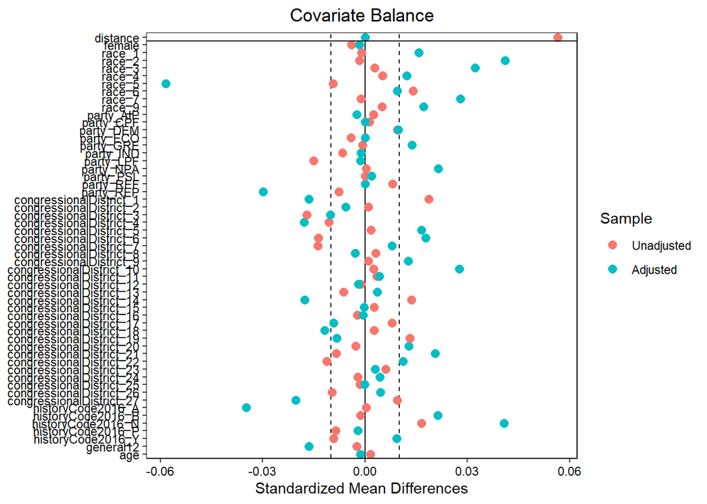

#### ATT estimate by nearest neighbor matching

```
##
## Call:
## lm(formula = outcome ~ treated, data = em1_m.data.nnm)
##
## Residuals:
##      Min       1Q   Median       3Q      Max
## -0.92616  0.07384  0.08258  0.08258  0.08258
##
## Coefficients:
##              Estimate Std. Error t value Pr(>|t|)
## (Intercept)  0.926158   0.001602 578.277  < 2e-16 ***
## treated     -0.008738   0.001970  -4.434 9.25e-06 ***
## ---
## Signif. codes:  0 '***' 0.001 '**' 0.01 '*' 0.05 '.' 0.1 ' ' 1
##
## Residual standard error: 0.2707 on 84166 degrees of freedom
## Multiple R-squared:  0.0002336,  Adjusted R-squared:  0.0002217
## F-statistic: 19.66 on 1 and 84166 DF,  p-value: 9.245e-06
```

### Exact matching

```
## Balance Measures
##                             Type Diff.Un Diff.Adj     M.Threshold
## female                    Binary -0.0020        0 Balanced, <0.01
## race_1                    Binary -0.0001        0 Balanced, <0.01
## race_2                    Binary -0.0002        0 Balanced, <0.01
## race_3                    Binary  0.0008        0 Balanced, <0.01
## race_4                    Binary  0.0020        0 Balanced, <0.01
## race_5                    Binary -0.0044        0 Balanced, <0.01
## race_6                    Binary  0.0016        0 Balanced, <0.01
## race_7                    Binary -0.0002        0 Balanced, <0.01
## race_9                    Binary  0.0005        0 Balanced, <0.01
## party_AIP                 Binary  0.0000        0 Balanced, <0.01
## party_CPF                 Binary  0.0000        0 Balanced, <0.01
## party_DEM                 Binary  0.0046        0 Balanced, <0.01
## party_ECO                 Binary -0.0000        0 Balanced, <0.01
## party_GRE                 Binary -0.0000        0 Balanced, <0.01
## party_IND                 Binary -0.0001        0 Balanced, <0.01
## party_LPF                 Binary -0.0010        0 Balanced, <0.01
## party_NPA                 Binary  0.0001        0 Balanced, <0.01
## party_PSL                 Binary  0.0000        0 Balanced, <0.01
## party_REF                 Binary  0.0001        0 Balanced, <0.01
## party_REP                 Binary -0.0037        0 Balanced, <0.01
## congressionalDistrict_1   Binary  0.0036        0 Balanced, <0.01
## congressionalDistrict_2   Binary  0.0002        0 Balanced, <0.01
## congressionalDistrict_3   Binary -0.0035        0 Balanced, <0.01
## congressionalDistrict_4   Binary -0.0019        0 Balanced, <0.01
## congressionalDistrict_5   Binary  0.0003        0 Balanced, <0.01
## congressionalDistrict_6   Binary -0.0022       -0 Balanced, <0.01
## congressionalDistrict_7   Binary -0.0018        0 Balanced, <0.01
## congressionalDistrict_8   Binary  0.0006        0 Balanced, <0.01
## congressionalDistrict_9   Binary  0.0002        0 Balanced, <0.01
## congressionalDistrict_10  Binary  0.0005        0 Balanced, <0.01
## congressionalDistrict_11  Binary  0.0007        0 Balanced, <0.01
## congressionalDistrict_12  Binary -0.0002        0 Balanced, <0.01
## congressionalDistrict_13  Binary -0.0014       -0 Balanced, <0.01
## congressionalDistrict_14  Binary  0.0029        0 Balanced, <0.01
## congressionalDistrict_15  Binary  0.0005        0 Balanced, <0.01
## congressionalDistrict_16  Binary -0.0005        0 Balanced, <0.01
## congressionalDistrict_17  Binary  0.0015        0 Balanced, <0.01
## congressionalDistrict_18  Binary  0.0006        0 Balanced, <0.01
```

[output cut: 17 more lines]

```
## Balance tally for mean differences
##                     count
## Balanced, <0.01        54
## Not Balanced, >0.01     0
##
## Variable with the greatest mean difference
##           Variable Diff.Adj     M.Threshold
##  historyCode2016_A        0 Balanced, <0.01
##
## Sample sizes
##                       Control Treated
## All                  55934.     55607
## Matched (ESS)        18360.65   28635
## Matched (Unweighted) 28974.     28635
## Unmatched            26960.     26972
```

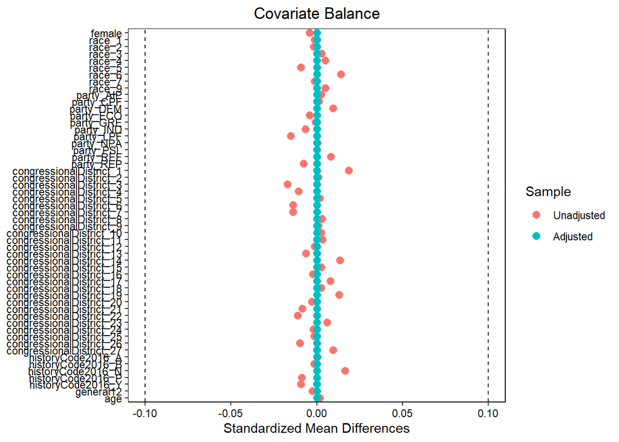

#### ATT estimate by exact matching

```
##
## Call:
## lm(formula = outcome ~ treated, data = em1_m.data.exa)
##
## Residuals:
##      Min       1Q   Median       3Q      Max
## -0.97632  0.02368  0.02368  0.02396  0.02396
##
## Coefficients:
##               Estimate Std. Error  t value Pr(>|t|)
## (Intercept)  0.9763236  0.0008958 1089.916   <2e-16 ***
## treated     -0.0002803  0.0012706   -0.221    0.825
## ---
## Signif. codes:  0 '***' 0.001 '**' 0.01 '*' 0.05 '.' 0.1 ' ' 1
##
## Residual standard error: 0.1525 on 57607 degrees of freedom
## Multiple R-squared:  8.448e-07,  Adjusted R-squared:  -1.651e-05
## F-statistic: 0.04867 on 1 and 57607 DF,  p-value: 0.8254
```

### Coarsened Exact Matching

```
## Balance Measures
##                             Type Diff.Un Diff.Adj     M.Threshold
## female                    Binary -0.0020   0.0000 Balanced, <0.01
## race_1                    Binary -0.0001   0.0000 Balanced, <0.01
## race_2                    Binary -0.0002   0.0000 Balanced, <0.01
## race_3                    Binary  0.0008   0.0000 Balanced, <0.01
## race_4                    Binary  0.0020   0.0000 Balanced, <0.01
## race_5                    Binary -0.0044   0.0000 Balanced, <0.01
## race_6                    Binary  0.0016   0.0000 Balanced, <0.01
## race_7                    Binary -0.0002   0.0000 Balanced, <0.01
## race_9                    Binary  0.0005   0.0000 Balanced, <0.01
## party_AIP                 Binary  0.0000   0.0000 Balanced, <0.01
## party_CPF                 Binary  0.0000   0.0000 Balanced, <0.01
## party_DEM                 Binary  0.0046   0.0000 Balanced, <0.01
## party_ECO                 Binary -0.0000   0.0000 Balanced, <0.01
## party_GRE                 Binary -0.0000   0.0000 Balanced, <0.01
## party_IND                 Binary -0.0001   0.0000 Balanced, <0.01
## party_LPF                 Binary -0.0010   0.0000 Balanced, <0.01
## party_NPA                 Binary  0.0001  -0.0000 Balanced, <0.01
## party_PSL                 Binary  0.0000   0.0000 Balanced, <0.01
## party_REF                 Binary  0.0001   0.0000 Balanced, <0.01
## party_REP                 Binary -0.0037   0.0000 Balanced, <0.01
## congressionalDistrict_1   Binary  0.0036   0.0000 Balanced, <0.01
## congressionalDistrict_2   Binary  0.0002   0.0000 Balanced, <0.01
## congressionalDistrict_3   Binary -0.0035  -0.0000 Balanced, <0.01
## congressionalDistrict_4   Binary -0.0019   0.0000 Balanced, <0.01
## congressionalDistrict_5   Binary  0.0003   0.0000 Balanced, <0.01
## congressionalDistrict_6   Binary -0.0022   0.0000 Balanced, <0.01
## congressionalDistrict_7   Binary -0.0018   0.0000 Balanced, <0.01
## congressionalDistrict_8   Binary  0.0006   0.0000 Balanced, <0.01
## congressionalDistrict_9   Binary  0.0002   0.0000 Balanced, <0.01
## congressionalDistrict_10  Binary  0.0005   0.0000 Balanced, <0.01
## congressionalDistrict_11  Binary  0.0007   0.0000 Balanced, <0.01
## congressionalDistrict_12  Binary -0.0002   0.0000 Balanced, <0.01
## congressionalDistrict_13  Binary -0.0014   0.0000 Balanced, <0.01
## congressionalDistrict_14  Binary  0.0029   0.0000 Balanced, <0.01
## congressionalDistrict_15  Binary  0.0005   0.0000 Balanced, <0.01
## congressionalDistrict_16  Binary -0.0005   0.0000 Balanced, <0.01
## congressionalDistrict_17  Binary  0.0015   0.0000 Balanced, <0.01
## congressionalDistrict_18  Binary  0.0006   0.0000 Balanced, <0.01
```

[output cut: 17 more lines]

```
## Balance tally for mean differences
##                     count
## Balanced, <0.01        54
## Not Balanced, >0.01     0
##
## Variable with the greatest mean difference
##  Variable Diff.Adj     M.Threshold
##       age  -0.0005 Balanced, <0.01
##
## Sample sizes
##                       Control Treated
## All                  55934.     55607
## Matched (ESS)        30634.73   44825
## Matched (Unweighted) 45388.     44825
## Unmatched            10546.     10782
```

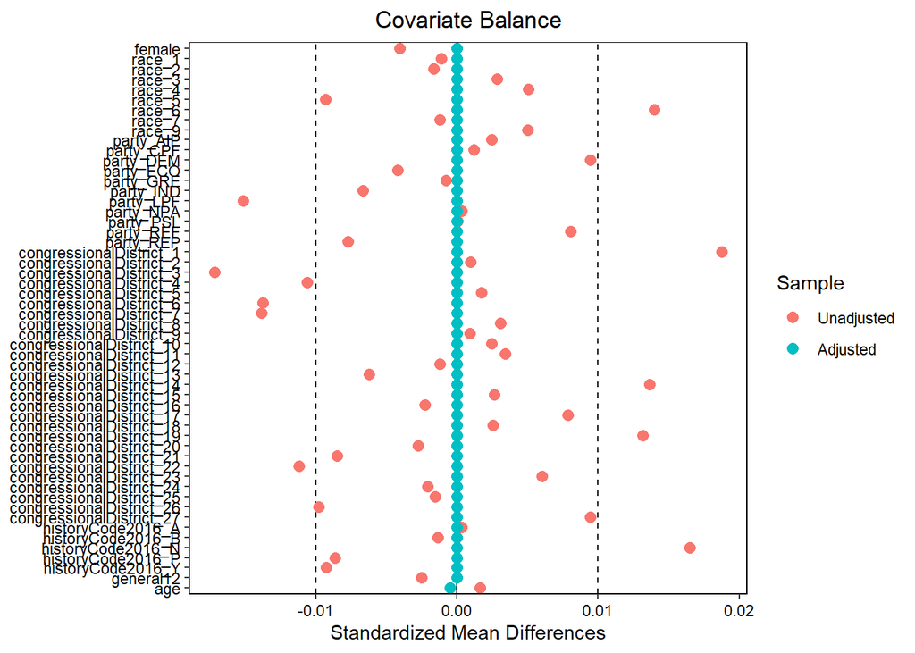

#### ATT estimate by CEM

```
##
## Call:
## lm(formula = outcome ~ treated, data = em1_m.data.cem)
##
## Residuals:
##      Min       1Q   Median       3Q      Max
## -0.95358  0.04642  0.04642  0.04743  0.04743
##
## Coefficients:
##               Estimate Std. Error t value Pr(>|t|)
## (Intercept)  0.9535780  0.0009926 960.659   <2e-16 ***
## treated     -0.0010069  0.0014082  -0.715    0.475
## ---
## Signif. codes:  0 '***' 0.001 '**' 0.01 '*' 0.05 '.' 0.1 ' ' 1
##
## Residual standard error: 0.2115 on 90211 degrees of freedom
## Multiple R-squared:  5.668e-06,  Adjusted R-squared:  -5.417e-06
## F-statistic: 0.5113 on 1 and 90211 DF,  p-value: 0.4746
```

### Comparing the ATT results from different matching

```
##
## Regression results after matching em1
## =====================================================================================================================
##                                                            Dependent variable:
##                     -------------------------------------------------------------------------------------------------
##                                                                  outcome
##                               (1)                       (2)                      (3)                    (4)
## ---------------------------------------------------------------------------------------------------------------------
## Constant                   0.7653***                 0.9262***                0.9763***              0.9536***
##                             (0.0016)                  (0.0016)                 (0.0009)               (0.0010)
##
## treated                     -0.0042*                 -0.0087***                -0.0003                -0.0010
##                             (0.0023)                  (0.0020)                 (0.0013)               (0.0014)
##
## ---------------------------------------------------------------------------------------------------------------------
## Observations                134,415                    84,168                   57,609                 90,213
## R2                          0.00002                    0.0002                  0.000001               0.00001
## Adjusted R2                 0.00002                    0.0002                  -0.00002               -0.00001
## Residual Std. Error   0.4251 (df = 134413)      0.2707 (df = 84166)      0.1525 (df = 57607)    0.2115 (df = 90211)
## F Statistic         3.2060* (df = 1; 134413) 19.6638*** (df = 1; 84166) 0.0487 (df = 1; 57607) 0.5113 (df = 1; 90211)
## =====================================================================================================================
## Note:                                                                                     *p<0.1; **p<0.05; ***p<0.01
```

# Vaccine incentives

## Experimental groups by treatment

```
## # A tibble: 3 × 2
##   Treatment      n
##   <chr>      <int>
## 1 treatment1   516
## 2 treatment2   562
## 3 treatment3   531
```

```
## # A tibble: 3 × 2
##   Treatment2                 n
##   <chr>                  <int>
## 1 CDC Health Information   516
## 2 Cash Voucher Incentive   531
## 3 Lottery Incentive        562
```

Control: treatment1(CDC Health Information)  
Treatment version 1: treatment2(Lottery Incentive)  
Treatment version 2: treatment3(Cash Voucher Incentive)